# Questionnaire Report for Warty sea cucumber

(MERA version 5.4.3)

Brett van Poorten (brett.vanpoorten@gmail.com)

2019-11-26

# About this document

This is a prototype of an automatic report that documents how the user specified the operating model and their various justifications.

# Introduction

1. Describe the history and current status of the fishery, including fleets, sectors, vessel types and practices/gear by vessel type, landing ports, economics/markets, whether targeted/bycatch, other stocks caught in the fishery. Sea cucumbers have been harvested on the coast for hundreds of years. The California fishery is assessed as ‘sea cucumbers’, which includes warty sea cucumbers and California sea cucumbers. Commercial lands were first recorded in Los Angeles in 1978. Combined annual landings for the commercial dive and trawl fisheries remained under 100,000 lbs until 1982, when the fishery expanded to adjacent areas. Initially, trawl landings dominated, but 1997-2002, diver harvest dominated, partly because of prosecution against illegal trawl harvest, and partly because of the collapse of adjacent diver fisheries. There is no significant recreational fishery. Warty sea cucumber are primarily caught by divers. Landings are primarily exported to Hong Kong, Taiwan, mainland China and South Korea; some are retained in California Asian markets as well.
2. Describe the stock’s ecosystem functions, dependencies, and habitat types. “The California sea cucumber is distributed from Baja California to Alaska. The warty sea cucumber is distributed from Baja California to Monterey Bay, although it is uncommon north of Pt. Conception. The California sea cucumber is found from the low intertidal to 300 feet (91 meters), and the warty sea cucumber is found from the low intertidal to 90 feet (27 meters), generally in areas with little water movement. Sea cucumbers are epibenthic detritivores that feed on organic detritus and small organisms within sediments and muds. Buccal tentacles trap food particles using an adhesive mucus. Sea cucumbers are non-selective with respect to grain size and ingest only the top few millimeters of sediment. One study of warty sea cucumbers around Santa Catalina Island found that those living on rock rubble were 27 percent smaller and seven times more numerous than those residing on sandy substrates. The detritus on rock rubble was found to have three times more organic material per gram compared to the detritus from the sand substrate, and sea cucumbers on the sand ingested eight times more sediment. In a recent study, California sea cucumbers were found to have the highest densities on shell debris, gravel, and boulders, and the lowest on mud and silt bottoms.” (2006 Warty Sea Cucumber Status.pdf)
3. Provide all relevant reference materials, such as assessments, research, and other analysis. 2006 Stock status: 2006 Sea Cucumber status.pdf Temperate sea cucumber status: Hamel, J.-F.; Mercier, A. 2008. Population status, fisheries and trade of sea cucumbers in temperate areas of the Northern Hemisphere. In V. Toral-Granda, A. Lovatelli and M. Vasconcellos (eds). Sea cucumbers. A global review of fisheries and trade. FAO Fisheries and Aquaculture Technical Paper. No. 516. Rome, FAO. pp. 257-291. (Temperate sea cucumber status.pdf) Continental Sea cucumber status: Bruckner, Andrew W. 2005. The recent status of sea cucumber fisheries in the continental United States of America. SPC Beche-de-mer Information Bulletin #22. (Bruckner 2005.pdf) Sea cucumber 2001 status report: CDFG 2001.pdf

# Fishery Characteristics

## Longevity

| Answered |
| --- |
| Very short-lived (5 < maximum age < 7) |
| Short-lived (7 < maximum age < 10) |
| Moderate life span (10 < maximum age < 20) |
| Moderately long-lived (20 < maximum age < 40) |
| Long-lived (40 < maximum age < 80) |
| Very long-lived (80 < maximum age < 160) |

| Justification |
| --- |
| Little biological information is known about the warty sea cucumber. This is particularly challenging because you can’t tag them and you can’t age them. Mortality rate is quite unknown. |

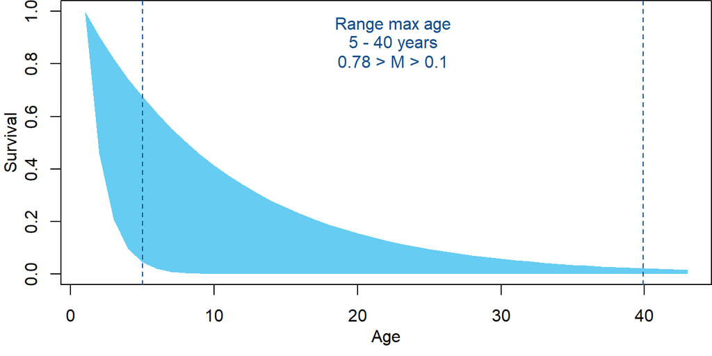

## Stock depletion

| Answered |
| --- |
| Crashed (D < 0.05) |
| Very depleted (0.05 < D < 0.1) |
| Depleted (0.1 < D < 0.15) |
| Moderately depleted (0.15 < D < 0.3) |
| Healthy (0.3 < D < 0.5) |
| Underexploited (0.5 < D) |

Justification

“Before–after, control–impact (BACI) analyses of seven fished and two non-fished sites [inside and outside marine reserves] implicated fishing mortality as the cause of 33–83% stock declines.” (Schroeter et al. 2001)  
“The Channel Islands National Parks Service has been monitoring warty sea cucumbers at 16 sites in the northern Channel Islands and Santa Barbara Island since 1982 (Figure 5.3). These fishery independent data show that populations of warty sea cucumber are variable but have been declining at fished sites since 1990.  
Meanwhile, sea cucumber catches from the dive fishery have increased at some of these sites. Recent analysis comparing population trends at fished sites to those of two small reserves where fishing is prohibited indicate that populations at fished sites range from 50 to more than 80 percent lower than at protected sites.  
Fishery independent sea cucumber density estimates have also been made using underwater video technology. Preliminary observations of California sea cucumbers in an established reserve in northern California (Point Cabrillo Marine Protected Area) at depths of 150 to 180 feet (46 to 55 meters) revealed densities averaging around 1,000 per acre (405 per hectare). By comparison, densities at a newly established reserve (Punta Gorda Ecological Reserve) were much lower, ranging from 120 to 350 per acre (49 to 142 per hectare). Only the large size classes were observed in these surveys, suggesting low levels of recruitment.” (2006 Sea Cucumber status.pdf)

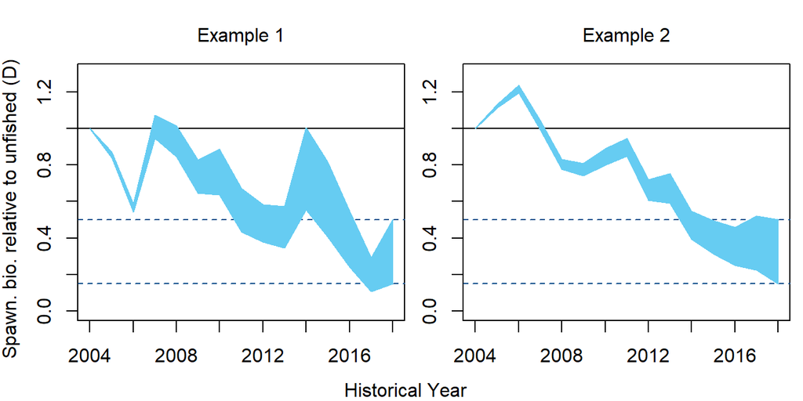

## Resilence

| Answered |
| --- |
| Not resilient (steepness < 0.3) |
| Low resilience (0.3 < steepness < 0.5) |
| Moderate resilence (0.5 < steepness < 0.7) |
| Resilient (0.7 < steepness < 0.9) |
| Very Resilient (0.9 < steepness) |

| Justification |
| --- |
| “Only the large size classes were observed in these surveys, suggesting low levels of recruitment.” (2006 Sea Cucumber status.pdf) |

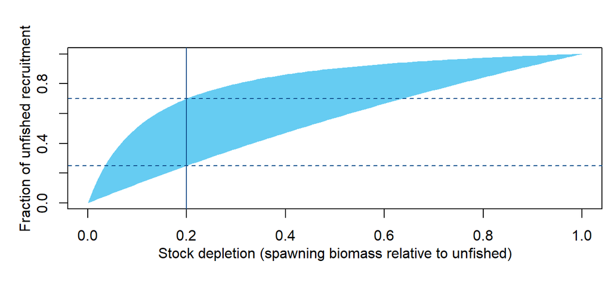

## Historical effort pattern

| Answered |
| --- |
| Stable |
| Two-phase |
| Boom-bust |
| Gradual increases |
| Stable, recent increases |
| Stable, recent declines |

Justification

Fishing effort (particularly trawl) increased through the 80-90s; several trawl licences were found to be fraudulent and the effort switched to primarily divers. Diving effort rose through shifts from other species. Total catch peaked in 2002. Trawl catch has remained constant, diver effort declined as other species were targeted.  
In 1997 a new system was enacted - limited total number of permits and needed separate permits for diving and trawling. Also had permit transfer fees; permits could be transferred from trawl to dive, but couldn’t transfer a dive to trawl. Maximum number of permits has declined as a result; from 113 dive and 36 trawl permits to 92 dive and 20 trawl permitees remaining. (2006 Sea Cucumber Status.pdf)

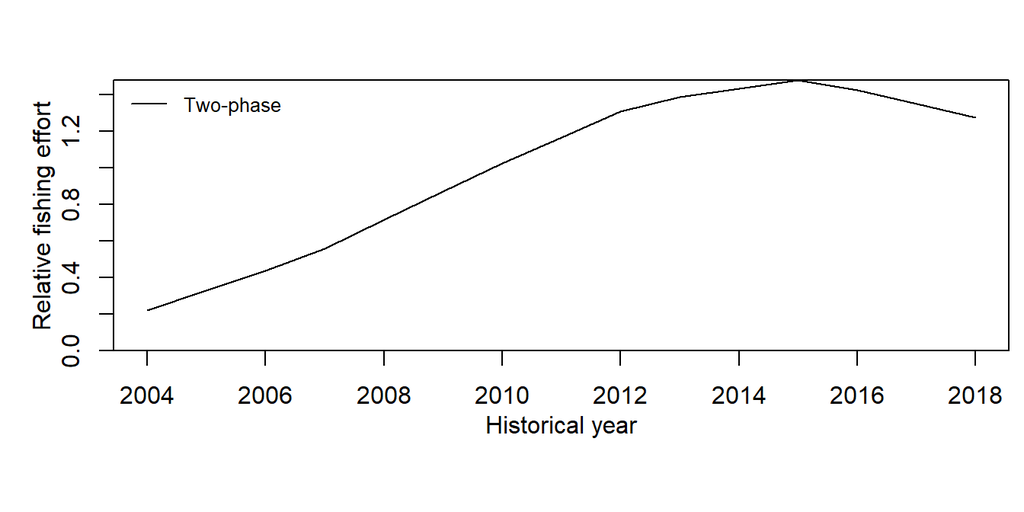

## Inter-annual variability in historical effort

| Answered |
| --- |
| Not variable (less than 20% inter-annual change (IAC)) |
| Variable (maximum IAC between 20% to 50%) |
| Highly variable (maximum IAC between 50% and 100%) |

| Justification |
| --- |
| No information on number of sea cucumber permits could be found. Recent permits have been declining. |

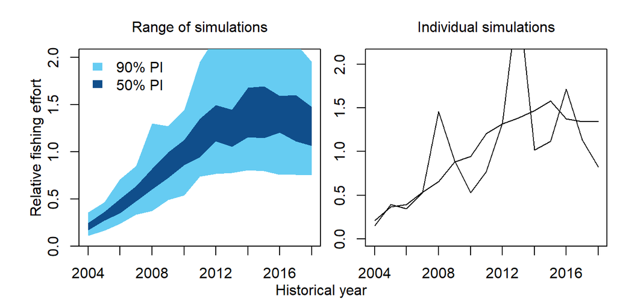

## Historical fishing efficiency changes

| Answered |
| --- |
| Declining by 2-3% pa (halves every 25-35 years) |
| Declining by 1-2% pa (halves every 35-70 years) |
| Stable -1% to 1% pa (may halve/double every 70 years) |
| Increasing by 1-2% pa (doubles every 35-70 years) |
| Increasing by 2-3% pa (doubles every 25-35 years) |

| Justification |
| --- |
| Fishing practices have remained stable. The only reason for increase in efficiency would be due to targeting known favourable habitats. |

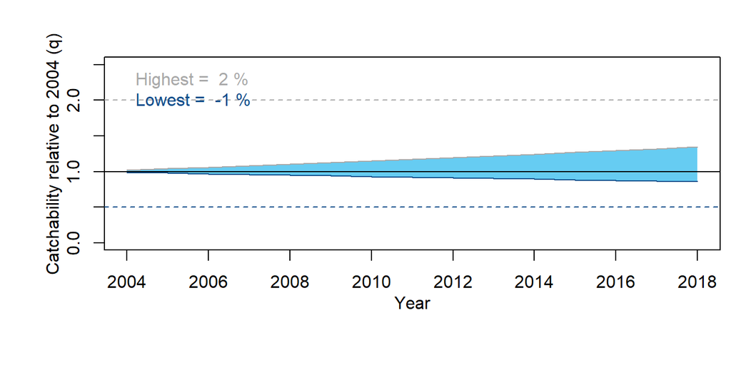

## Future fishing efficiency changes

| Answered |
| --- |
| Declining by 2-3% pa (halves every 25-35 years) |
| Declining by 1-2% pa (halves every 35-70 years) |
| Stable -1% to 1% pa (may halve/double every 70 years) |
| Increasing by 1-2% pa (doubles every 35-70 years) |
| Increasing by 2-3% pa (doubles every 25-35 years) |

| Justification |
| --- |
| Increased knowledge of habitat preferences of areas and times of aggregation will likely lead to increased efficiency in future |

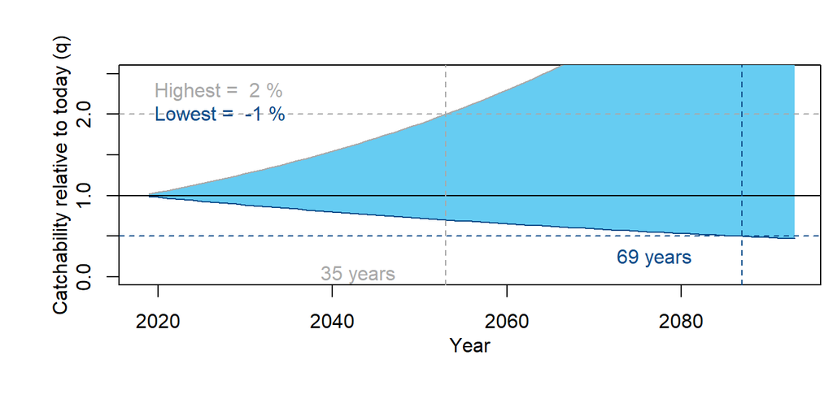

## Length at maturity

| Answered |
| --- |
| Very small (0.4 < LM < 0.5) |
| Small (0.5 < LM < 0.6) |
| Moderate (0.6 < LM < 0.7) |
| Moderate to large (0.7 < LM < 0.8) |
| Large (0.8 < LM < 0.9) |

Justification

“Parastichopus parvimensis does not become sexually mature until it reaches ca. 40 g in total body weight (Muscat, 1983)” - citation from (Population status, fisheries  
and trade of sea cucumbers in temperate areas of the Northern Hemisphere)  
-Muscat, A.M. 1982. Aspects of the biology of the sea cucumber, Parastichopus parvimensis: a developing commercial fishery (R-RD-14). The Planning and Management of California’s Coastal Resources. USC Sea Grant Institutional Program 1981-82, Trainee Report, University of Southern California, pp. 25–27.  
Warty sea cucumbers grow to 30-40 cm (Bruckner 2006)

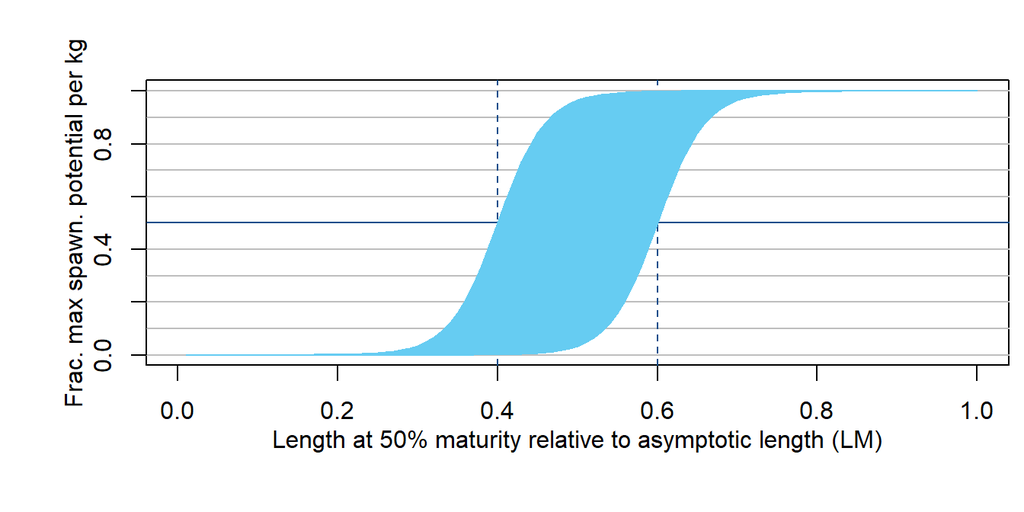

## Selectivity of small fish

| Answered |
| --- |
| Very small (0.1 < S < 0.2) |
| Small (0.2 < S < 0.4) |
| Half asymptotic length (0.4 < S < 0.6) |
| Large (0.6 < S < 0.8) |
| Very large (0.8 < S < 0.9) |

| Justification |
| --- |
| No information on captured sizes are given. |

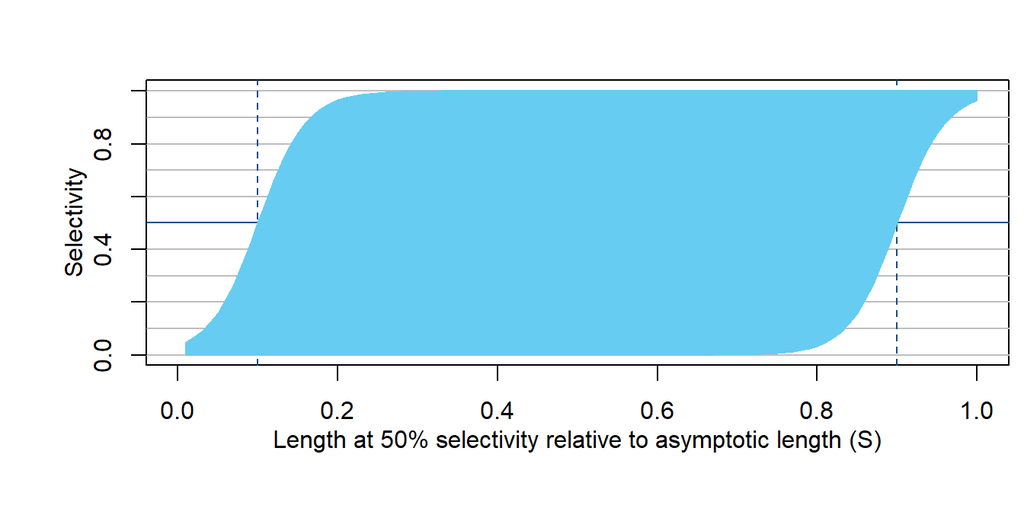

## Selectivity of large fish

| Answered |
| --- |
| Asymptotic selectivity (SL = 1) |
| Declining selectivity with length (0.75 < SL < 1) |
| Dome-shaped selectivity (0.25 < SL < 0.75) |
| Strong dome-shaped selectivity (SL < 0.25) |

| Justification |
| --- |
| No information on captured sizes are given. |

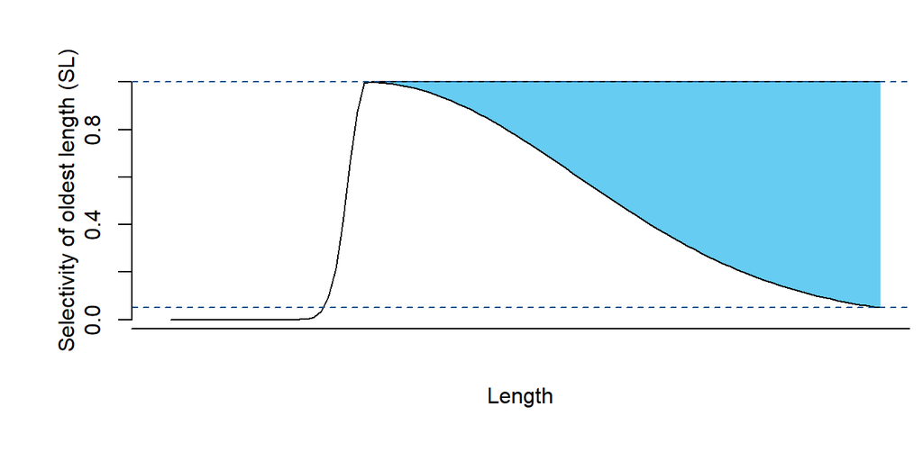

## Discard rate

| Answered |
| --- |
| Low (DR < 1%) |
| Low - moderate (1% < DR < 10%) |
| Moderate (10% < DR < 30%) |
| Moderate - high (30% < DR < 50%) |
| High (50% < DR < 70%) |

| Justification |
| --- |
| No information given. These appear to be relatively resilient given they can eviscerate their internal organs and regrow. I presume a released sea cucumber would live fine thereafter. |

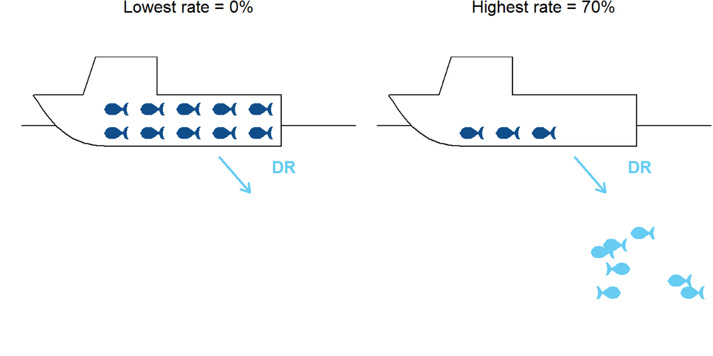

## Post-release mortality rate

| Answered |
| --- |
| Low (PRM < 5%) |
| Low - moderate (5% < PRM < 25%) |
| Moderate (25% < PRM < 50%) |
| Moderate - high (50% < PRM < 75%) |
| High (75% < PRM < 95%) |
| Almost all die (95% < PRM < 100%) |

[output not shown]

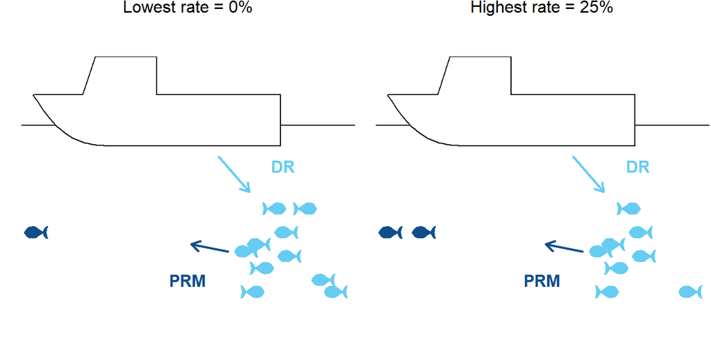

## Recruitment variability

| Answered |
| --- |
| Very low (less than 20% inter-annual changes (IAC)) |
| Low (max IAC of between 20% and 60%) |
| Moderate (max IAC of between 60% and 120%) |
| High (max IAC of between 120% and 180%) |
| Very high (max IAC greater than 180%) |

[output not shown]

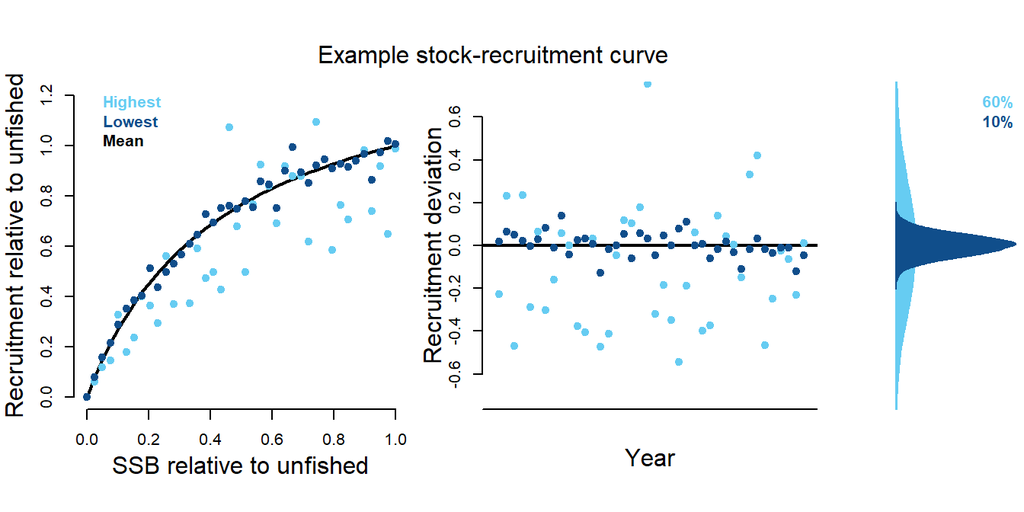

## Size of an existing MPA

| Answered |
| --- |
| None |
| Small (A < 5%) |
| Small-moderate (5% < A < 10%) |
| Moderate (10% < A < 20%) |
| Large (20% < A < 30%) |
| Very large (30% < A < 40%) |
| Huge (40% < A < 50%) |

[output not shown]

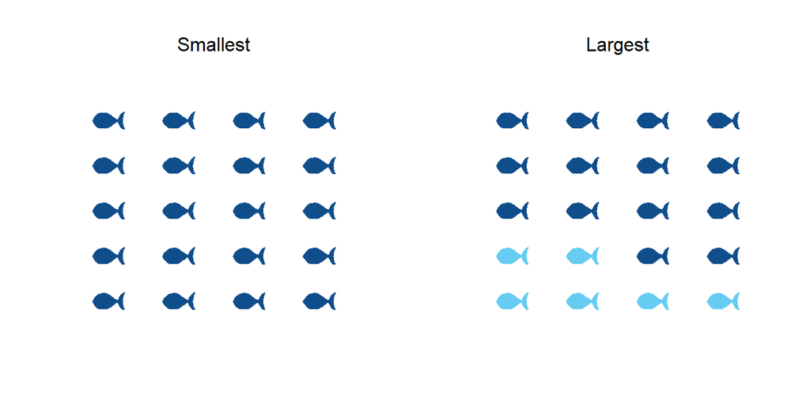

## Spatial mixing (movement) in/out of existing MPA

| Answered |
| --- |
| Very low (P < 1%) |
| Low (1% < P < 5%) |
| Moderate (5% < P < 10%) |
| High (10% < P < 20%) |
| Fully mixed |

[output not shown]

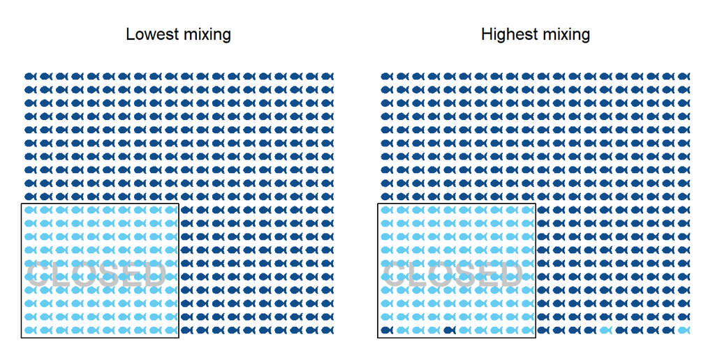

## Size of a future potential MPA

| Answered |
| --- |
| None |
| Small (A < 5%) |
| Small-moderate (5% < A < 10%) |
| Moderate (10% < A < 20%) |
| Large (20% < A < 30%) |
| Very large (30% < A < 40%) |
| Huge (40% < A < 50%) |

| Justification |
| --- |
| There are currently marine reserves; there is no plan to remove them. |

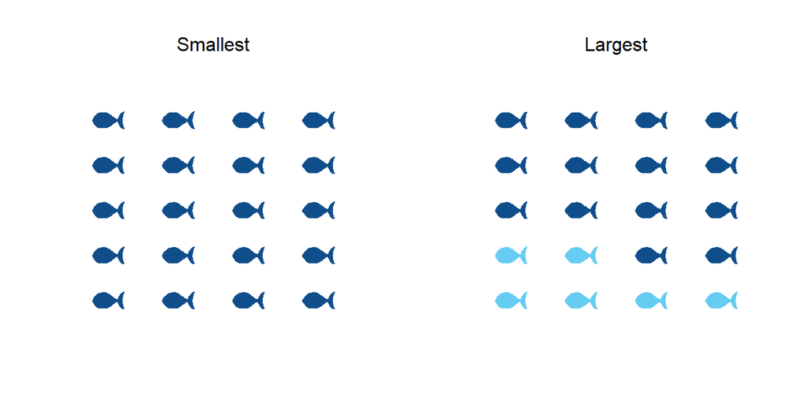

## Spatial mixing (movement) in/out of future potential MPA

| Answered |
| --- |
| Very low (P < 1%) |
| Low (1% < P < 5%) |
| Moderate (5% < P < 10%) |
| High (10% < P < 20%) |
| Fully mixed |

| Justification |
| --- |
| Sea cucumbers move an average of 4m per day. |

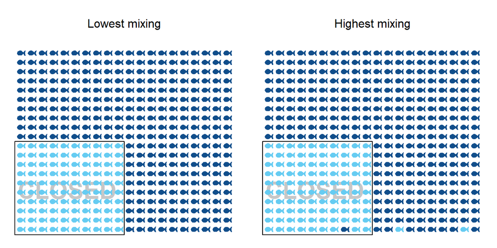

## Initial stock depletion

| Answered |
| --- |
| Very low (0.1 < D1 < 0.15) |
| Low (0.15 < D1 < 0.3) |
| Moderate (0.3 < D < 0.5) |
| High (0.5 < D1) |
| Asymptotic unfished levels (D1 = 1) |

| Justification |
| --- |
| Sea cucumbers have been fished for centuries, but a directed fishery started in 1978. It is assumed that the population was close to unfished at this point. |

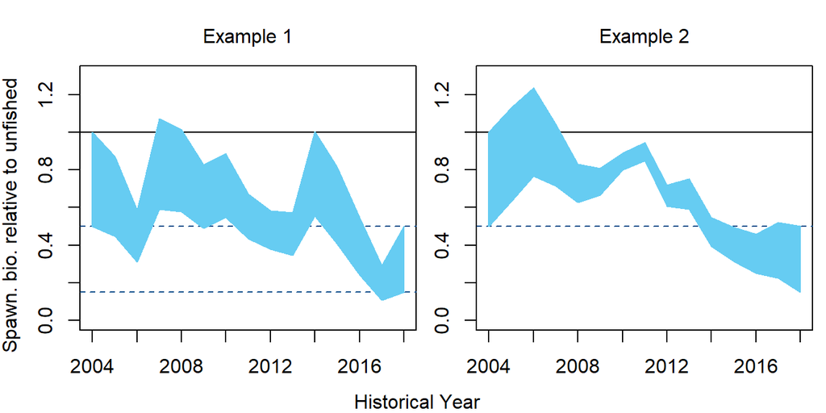